# Group_Project

Feiya Wang

11/11/2019

## **Group Project–Species Distribution Model**

It is a Group projetc worked by Majo, Frank and Feiya

# Introduction: short paragraph and an image

In this module we provide a short summary to species distribution modelling in R. This module will cover a brief overview of the concept of species distribution modelling and the basic modelling steps.

Species distribution modeling (SDM) is also known under other names including climate envelope-modeling, habitat modeling, and (environmental or ecological) niche-modeling.

The aim of SDM is to estimate the similarity of the conditions at any site to the conditions at the locations of known occurrence (and perhaps of non-occurrence) of a phenomenon. A common application of this method is to predict species ranges with climate data as predictors.

SDM steps:

1. locations of occurrence of a species (or other phenomenon) are compiled
2. values of environmental predictor variables (such as climate) at these locations are extracted from spatial databases
3. the environmental values are used to fit a model to estimate similarity to the sites of occurrence, or another measure such as abundance of the species
4. The model is used to predict the variable of interest across the region of interest (and perhaps for a future or past climate).

Notes: Before you begin you will need to install the following packages and their dependencies:

- dismo
- raster
- rJava
- rgdal
- rgbif

Follow a brief description of the main packages that we will use in this module: dismo (=“distribution modeling”), and raster (=“geographic data analysis and modelling”), and each one of them has a set of functions that enable to modelling species distribution in geographic and spatial contexts

# Step 1: Data preparation

You need to collect a sufficient number of occurrence records (and absence or abundance, if possible) of the species of interest. You also need to have accurate an relevant environmental data (predictor variables) at sufficient high spatial resolution.

[figure not shown]

# Step 2: Import Species occurrence data

Importing occurrence data into R is easy. But collecting, georeferencing, and cross-checking coordinate data is tedious

> 1.Upload files

If You have a files, than you can upload it like we did in previous class, using curl package.

For example:

```r
library (curl)
#install package curl before this step to load a file from server.
library(knitr)
# to make nice data table.

f <- curl("https://raw.githubusercontent.com/feiyawang1207/AN597_groupproject/master/S_angustifolium.csv")
#load the file in varibale f
d <- read.csv(f, header = TRUE, sep = "\t", stringsAsFactors = FALSE)
# read file in d as a dataframe.
kable(head(d))
```

| gbifID | datasetKey | occurrenceID | kingdom | phylum | class | order | family | genus | species | infraspecificEpithet | taxonRank | scientificName | verbatimScientificName | verbatimScientificNameAuthorship | countryCode | locality | stateProvince | occurrenceStatus | individualCount | publishingOrgKey | decimalLatitude | decimalLongitude | coordinateUncertaintyInMeters | coordinatePrecision | elevation | elevationAccuracy | depth | depthAccuracy | eventDate | … |
| --- | --- | --- | --- | --- | --- | --- | --- | --- | --- | --- | --- | --- | --- | --- | --- | --- | --- | --- | --- | --- | --- | --- | --- | --- | --- | --- | --- | --- | --- | --- |
| 2451752339 | 50c9509d-22c7-4a22-a47d-8c48425ef4a7 | https://www.inaturalist.org/observations/35412543 | Plantae | Tracheophyta | Magnoliopsida | Solanales | Solanaceae | Solanum | Solanum angustifolium | NA | SPECIES | Solanum rostratum Dun. | Solanum rostratum |  | MX |  | Michoacán |  | NA | 28eb1a3f-1c15-4a95-931a-4af90ecb574d | 19.07638 | -102.88527 | 22 | NA | NA | NA | NA | NA | 2019-11-07T09:40:48Z | … |
| 2451721667 | 50c9509d-22c7-4a22-a47d-8c48425ef4a7 | https://www.inaturalist.org/observations/35294114 | Plantae | Tracheophyta | Magnoliopsida | Solanales | Solanaceae | Solanum | Solanum angustifolium | NA | SPECIES | Solanum rostratum Dun. | Solanum rostratum |  | MX |  | Jalisco |  | NA | 28eb1a3f-1c15-4a95-931a-4af90ecb574d | 21.36370 | -101.94901 | 4 | NA | NA | NA | NA | NA | 2019-11-03T14:32:00Z | … |
| 2451686769 | 50c9509d-22c7-4a22-a47d-8c48425ef4a7 | https://www.inaturalist.org/observations/35175230 | Plantae | Tracheophyta | Magnoliopsida | Solanales | Solanaceae | Solanum | Solanum angustifolium | NA | SPECIES | Solanum rostratum Dun. | Solanum rostratum |  | US |  | Texas |  | NA | 28eb1a3f-1c15-4a95-931a-4af90ecb574d | 32.69588 | -102.25799 | 8 | NA | NA | NA | NA | NA | 2019-11-01T15:15:39Z | … |
| 2451656431 | 50c9509d-22c7-4a22-a47d-8c48425ef4a7 | https://www.inaturalist.org/observations/35013197 | Plantae | Tracheophyta | Magnoliopsida | Solanales | Solanaceae | Solanum | Solanum angustifolium | NA | SPECIES | Solanum rostratum Dun. | Solanum rostratum |  | US |  | Texas |  | NA | 28eb1a3f-1c15-4a95-931a-4af90ecb574d | 30.22526 | -99.01538 | 6 | NA | NA | NA | NA | NA | 2019-10-28T11:53:22Z | … |
| 2451601084 | 50c9509d-22c7-4a22-a47d-8c48425ef4a7 | https://www.inaturalist.org/observations/34881947 | Plantae | Tracheophyta | Magnoliopsida | Solanales | Solanaceae | Solanum | Solanum angustifolium | NA | SPECIES | Solanum rostratum Dun. | Solanum rostratum |  | US |  | Arkansas |  | NA | 28eb1a3f-1c15-4a95-931a-4af90ecb574d | 36.44975 | -94.59106 | 10 | NA | NA | NA | NA | NA | 2019-08-21T13:59:00Z | … |
| 2451556298 | 1060a696-f6a2-4341-92ef-47a63babbea1 | 7526a2b2-b355-492e-9d57-7de5519acd6e | Plantae | Tracheophyta | Magnoliopsida | Solanales | Solanaceae | Solanum | Solanum angustifolium | NA | SPECIES | Solanum rostratum Dun. | Solanum rostratum | Dunal | US | by Hwy 30 c. 10 mi W of Sidney | Nebraska |  | NA | 75bf5fec-40fa-43ae-919f-c43bd7ce25c9 | NA | NA | NA | NA | NA | NA | NA | NA | 1945-08-21T00:00:00Z | … |

> 2.Importing occurrence data

If you do not have any species distribution data you can get started by downloading data from the [Global Biodiversity Inventory Facility (GBIF)!](https://www.gbif.org) There you can find *1.354.603.236* Occurrence records

To importing data from a database, we use a function called [gbif ()!](https://www.rdocumentation.org/packages/dismo/versions/1.1-4/topics/gbif) to download the files from [GBIF!](https://www.gbif.org) database.

We are going to download the occurrence data from a potato species. *Solanum acaule* is widespread and common in upland habitats from northern Peru (Dept. Cajamarca), south through Bolivia to northern Argentina (Prov. San Juan), and with one record in northern Chile (Antofagasta Region)

```r
library(dismo)
library(knitr)

acaule <- gbif("solanum", "acaule*", geo=FALSE)
```

```
## 7229 records found
```

```
## 0-300-600-900-1200-1500-1800-2100-2400-2700-3000-3300-3600-3900-4200-4500-4800-5100-5400-5700-6000-6300-6600-6900-7200-7229 records downloaded
```

```r
#load the saved S. acaule data from data base

kable(head(acaule))
```

| acceptedScientificName | acceptedTaxonKey | accessRights | adm1 | adm2 | associatedReferences | basisOfRecord | bibliographicCitation | catalogNumber | class | classKey | cloc | collectionCode | collectionID | continent | coordinateUncertaintyInMeters | country | crawlId | datasetID | datasetKey | datasetName | dateIdentified | day | depth | depthAccuracy | disposition | dynamicProperties | elevation | elevationAccuracy | endDayOfYear | … |
| --- | --- | --- | --- | --- | --- | --- | --- | --- | --- | --- | --- | --- | --- | --- | --- | --- | --- | --- | --- | --- | --- | --- | --- | --- | --- | --- | --- | --- | --- | --- |
| Solanum acaule Bitter | 2931061 | NA | Cusco | NA | NA | HUMAN_OBSERVATION | NA | 22332967 | Magnoliopsida | 220 | Cusco, Peru | Observations | NA | NA | 300 | Peru | 190 | NA | 50c9509d-22c7-4a22-a47d-8c48425ef4a7 | iNaturalist research-grade observations | 2019-04-30T14:41:30 | 26 | NA | NA | NA | NA | NA | NA | NA | … |
| Solanum acaule Bitter | 2931061 | NA | Catamarca | Ambato | NA | PRESERVED_SPECIMEN | NA | CORD00056696 | Magnoliopsida | 220 | Camino desde El Rodeo rumbo a Primer Campo. Puesto Vergara, Primer Campo, alrededores de la Casa de Piedra, Catamarca, Ambato, Argentina, SOUTH_AMERICA | NA | NA | SOUTH_AMERICA | NA | Argentina | 15 | NA | ab61ad8f-953f-4c7c-80b2-e1fb50fd8187 | NA | 2016-01-01T00:00:00 | 24 | NA | NA | NA | NA | NA | NA | NA | … |
| Solanum acaule Bitter | 2931061 | NA | Lima | NA | NA | PRESERVED_SPECIMEN | NA | BM001134709 | Magnoliopsida | 220 | Huaroz district, 37 km from canta on road to La Viuda, Lima, Peru, SOUTH_AMERICA | BOT | NA | SOUTH_AMERICA | NA | Peru | 142 | NA | 7e380070-f762-11e1-a439-00145eb45e9a | NA | NA | 28 | NA | NA | NA | {“determinationfiledas”: “Yes”, “collectionkind”: “Sheet”, “gbifissue”: [“GEODETIC_DATUM_ASSUMED_WGS84”], “created”: 1415984060000, “associatedmediacount”: 1, “project”: “Picturae”, “determinationname… | 4052 | NA | NA | … |
| Solanum acaule Bitter | 2931061 | NA | Lima | Canta | NA | PRESERVED_SPECIMEN | http://www.tropicos.org/Specimen/100991187 | 100991187 | Magnoliopsida | 220 | Huaroz district, 37 km from Canta on road to La Viuda., Lima, Canta, Peru, SOUTH_AMERICA | MO | http://biocol.org/urn:lsid:biocol.org:col:15859 | SOUTH_AMERICA | NA | Peru | 95 | NA | 7bd65a7a-f762-11e1-a439-00145eb45e9a | Tropicos | NA | 28 | NA | NA | NA | NA | 4052 | NA | NA | … |
| Solanum acaule Bitter | 2931061 | NA | Lima | Oyon | NA | PRESERVED_SPECIMEN | http://www.tropicos.org/Specimen/100991022 | 100991022 | Magnoliopsida | 220 | Oyón district, 1.7 km up to Quichas on road up to Cordillera Raura., Lima, Oyon, Peru, SOUTH_AMERICA | MO | http://biocol.org/urn:lsid:biocol.org:col:15859 | SOUTH_AMERICA | NA | Peru | 95 | NA | 7bd65a7a-f762-11e1-a439-00145eb45e9a | Tropicos | NA | 6 | NA | NA | NA | NA | 4134 | NA | NA | … |
| Solanum acaule Bitter | 2931061 | NA | Ancash | NA | NA | PRESERVED_SPECIMEN | NA | BM001120832 | Magnoliopsida | 220 | between km55-57 on rd from Yanac to Sihuas, Ancash, Peru, SOUTH_AMERICA | BOT | NA | SOUTH_AMERICA | NA | Peru | 142 | NA | 7e380070-f762-11e1-a439-00145eb45e9a | NA | NA | 19 | NA | NA | NA | {“determinationfiledas”: “Yes”, “collectionkind”: “Sheet”, “gbifissue”: [“GEODETIC_DATUM_ASSUMED_WGS84”], “created”: 1415986484000, “associatedmediacount”: 1, “project”: “Picturae”, “determinationname… | 3955 | NA | NA | … |

If you want to check how many rows and colums the data frame you have, we use [dim ()!](https://www.rdocumentation.org/packages/base/versions/3.6.1/topics/dimto) to show the dimension of the dataset.

```r
colrow<-dim(acaule)
# use dim() to get dimension of our dataset

colrow[1]
```

```
## [1] 7229
```

```r
#show row numbers

y<-colrow[2]
#show column number
```

In order to drawing a map, we need to find the location by Longitude and latitude from dataset.

Subetting the data that have longitude and latitude. Many occurence records may not have geographic coordinates, so you will need to remove those NA values from your dataframe. We use is.na() to test the data that have both longitude and latitude data and make them into a data frame.

```r
acgeo <- subset(acaule, !is.na(lon) & !is.na(lat))
#use subset() to seperate those data

#datatable(head(acgeo))
#showing the example data see that have longtitude and latitude data

dim(acgeo)
```

```
## [1] 4643  127
```

```r
#showing the rows and columns for data frame
```

```r
acgeo[1:4, c(1:5,7:10)] #removing locality
```

```
##   acceptedScientificName acceptedTaxonKey accessRights      adm1   adm2
## 1  Solanum acaule Bitter          2931061         <NA>     Cusco   <NA>
## 2  Solanum acaule Bitter          2931061         <NA> Catamarca Ambato
## 3  Solanum acaule Bitter          2931061         <NA>      Lima   <NA>
## 4  Solanum acaule Bitter          2931061         <NA>      Lima  Canta
##        basisOfRecord                      bibliographicCitation
## 1  HUMAN_OBSERVATION                                       <NA>
## 2 PRESERVED_SPECIMEN                                       <NA>
## 3 PRESERVED_SPECIMEN                                       <NA>
## 4 PRESERVED_SPECIMEN http://www.tropicos.org/Specimen/100991187
##   catalogNumber         class
## 1      22332967 Magnoliopsida
## 2  CORD00056696 Magnoliopsida
## 3   BM001134709 Magnoliopsida
## 4     100991187 Magnoliopsida
```

> 3. Making a map of the ocurrence localities

We use solanum acaule as an example

In order to do that, we need package maptools.

First, we need to draw a empty map. a variable called [wrld_simpl!](https://www.rdocumentation.org/packages/maptools/versions/0.9-8/topics/wrld_simpl) will show a empty world-wide map. The wrld_simpl dataset contains rough country outlines.

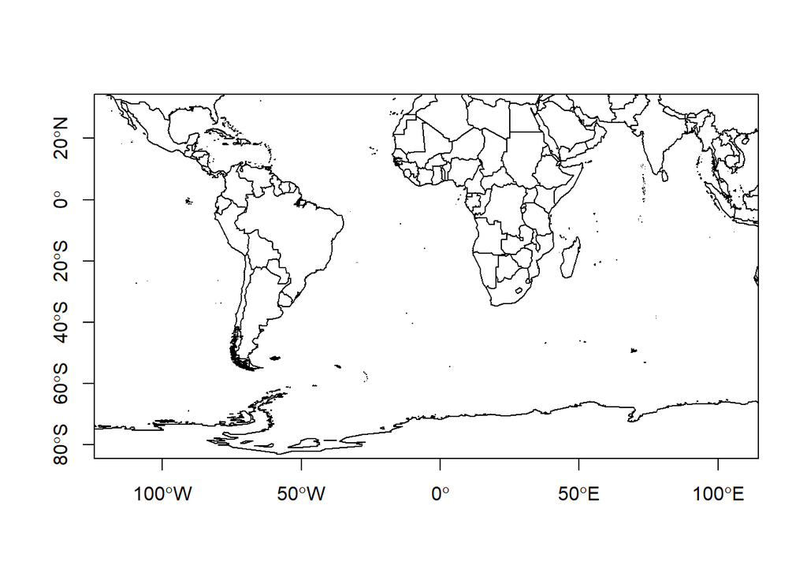

```r
library(maptools)
data(wrld_simpl)
x<-plot(wrld_simpl, xlim=c(-80,70), ylim=c(-80,30), axes=TRUE)
```

```r
# empty map
```

Then we need to add our data points. It is important to make such maps to assure that the points are, at least roughly, in the right location

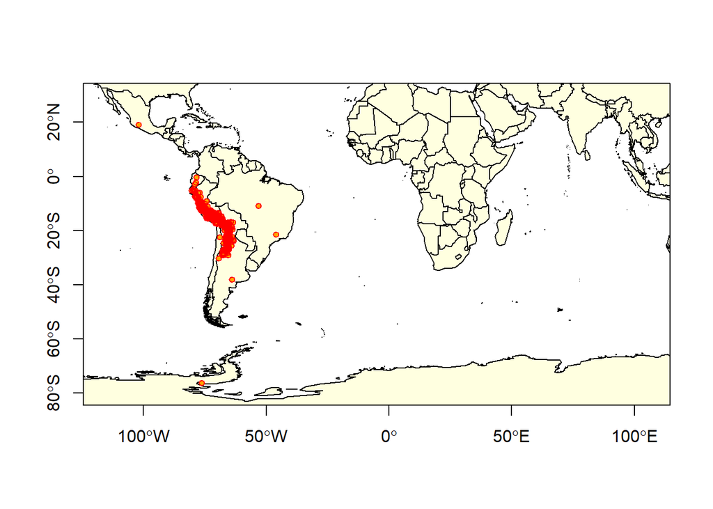

```r
library(maptools)

data(wrld_simpl)
plot(wrld_simpl, xlim=c(-80,70), ylim=c(-80,30), axes=TRUE, col="light yellow")
# restore the box around the map
box()
# add the points
points(acgeo$lon, acgeo$lat, col='orange', pch=20, cex=0.75)
# plot points again to add a border, for better visibility
points(acgeo$lon, acgeo$lat, col='red', cex=0.75)
```

```r
 r <- raster(system.file("external/test.grd", package="raster"))
```

> 4. Data cleaning

[figure not shown]

Data ‘cleaning’ is particularly important for data sourced from species distribution data warehouses such as GBIF. Solanum acaule is a species that occurs in the higher parts of the Andes mountains of southern Peru, Bolivia and northern Argentina.

We imported more than seven thousand records, but not all of these are usable because of various issues. This species is distributed mainly in the Andes mountains of southern Peru, Bolivia and northern Argentina, but as you can see in the previous map there are records in other countries and even in the Antartica. In order to clean this data we will need to: a) avoid false identifications, b) use only specimens collected in a period relevant to the climate data we will be utilizing, and c) have reliable locational certainty (the cleaning will depend of the species we are modelling and the data availability).

```r
acaule[c(303,885),1:10]
```

```
##     acceptedScientificName acceptedTaxonKey accessRights       adm1
## 303  Solanum acaule Bitter          2931061         <NA>      Cusco
## 885  Solanum acaule Bitter          2931061         <NA> Cochabamba
##        adm2 associatedReferences basisOfRecord bibliographicCitation
## 303   Canas                 <NA>       UNKNOWN                  <NA>
## 885 Chapare                 <NA>       UNKNOWN                  <NA>
##     catalogNumber         class
## 303       2756254 Magnoliopsida
## 885       2758955 Magnoliopsida
```

```r
lonzero = subset(acgeo, lon==0)
lonzero[, 1:13]
```

```
##  [1] acceptedScientificName acceptedTaxonKey       accessRights
##  [4] adm1                   adm2                   associatedReferences
##  [7] basisOfRecord          bibliographicCitation  catalogNumber
## [10] class                  classKey               cloc
## [13] collectionCode
## <0 rows> (or 0-length row.names)
```

The records might come from different sources, sometimes from museum collections or zoos. Be sure to choose only the kind of records you really want

```r
unique(acaule$basisOfRecord)#if you want to know origin of your records.
```

```
## [1] "HUMAN_OBSERVATION"  "PRESERVED_SPECIMEN" "LIVING_SPECIMEN"
## [4] "UNKNOWN"
```

```r
#You can either decide to work with specimens stored only in  scientific collections or include all records in your analysis.
acaule1 <- subset(acaule,
    basisOfRecord=="specimen" |
    basisOfRecord=="unknown" |
    basisOfRecord=="living"
    )
nrow(acaule1)
```

```
## [1] 0
```

> 5.Duplicate records: The next function helps to remove duplicates.

```r
#which records are duplicates (only for the first 10 columns)?
dups <- duplicated(lonzero[, 1:10])
#remove duplicates
lonzero  <-  lonzero[dups, ]
lonzero[,1:13]
```

```
##  [1] acceptedScientificName acceptedTaxonKey       accessRights
##  [4] adm1                   adm2                   associatedReferences
##  [7] basisOfRecord          bibliographicCitation  catalogNumber
## [10] class                  classKey               cloc
## [13] collectionCode
## <0 rows> (or 0-length row.names)
```

Another approach might be to detect duplicates for the same species and some coordinates in the data, even if the records were from collections by different people or in different years (in our case, using species is redundant as we have data for only one species).

```r
# differentiating by (sub) species
# dups2 <- duplicated(acgeo[, c('species', 'lon', 'lat')])
# ignoring (sub) species and other naming variation
dups2 <- duplicated(acgeo[, c('lon', 'lat')])
# number of duplicates
sum(dups2)
```

```
## [1] 2345
```

```r
## [1] 483
# keep the records that are _not_ duplicated
acg <- acgeo[!dups2, ]
```

```r
i <- acg$lon > 0 & acg$lat > 0
acg$lon[i] <- -1 * acg$lon[i]
acg$lat[i] <- -1 * acg$lat[i]
acg <- acg[acg$lon < -50 & acg$lat > -50, ]
```

> 6. Cross-checking:

```r
library(sp)
coordinates(acg) <- ~lon+lat
crs(acg) <- crs(wrld_simpl)
class(acg)
```

```
## [1] "SpatialPointsDataFrame"
## attr(,"package")
## [1] "sp"
```

```r
## [1] "SpatialPointsDataFrame"
## attr(,"package")
## [1] "sp"
```

```r
class(wrld_simpl)
```

```
## [1] "SpatialPolygonsDataFrame"
## attr(,"package")
## [1] "sp"
```

```r
## [1] "SpatialPolygonsDataFrame"
## attr(,"package")
## [1] "sp"
ovr <- over(acg, wrld_simpl)
```

```r
head(ovr)
```

```
##   FIPS ISO2 ISO3  UN      NAME   AREA  POP2005 REGION SUBREGION     LON
## 1   PE   PE  PER 604      Peru 128000 27274266     19         5 -75.552
## 2   AR   AR  ARG  32 Argentina 273669 38747148     19         5 -65.167
## 3   PE   PE  PER 604      Peru 128000 27274266     19         5 -75.552
## 4   PE   PE  PER 604      Peru 128000 27274266     19         5 -75.552
## 5   PE   PE  PER 604      Peru 128000 27274266     19         5 -75.552
## 6   PE   PE  PER 604      Peru 128000 27274266     19         5 -75.552
##       LAT
## 1  -9.326
## 2 -35.377
## 3  -9.326
## 4  -9.326
## 5  -9.326
## 6  -9.326
```

```r
cntr <- ovr$NAME
```

```r
i <- which(is.na(cntr))
i
```

```
## integer(0)
```

```r
## integer(0)
j <- which(cntr != acg$country)
# for the mismatches, bind the country names of the polygons and points
cbind(cntr, acg$country)[j,]
```

```
##       cntr
##  [1,] "27"  "Argentina"
##  [2,] "27"  "Argentina"
##  [3,] "27"  "Argentina"
##  [4,] "172" "Bolivia"
##  [5,] "172" "Bolivia"
##  [6,] "172" "Bolivia"
##  [7,] "27"  "Argentina"
##  [8,] "27"  "Argentina"
##  [9,] "172" "Bolivia"
## [10,] "172" "Bolivia"
## [11,] "172" "Bolivia"
## [12,] "172" "Bolivia"
## [13,] "172" "Bolivia"
## [14,] "172" "Bolivia"
```

[output cut: 53 more lines]

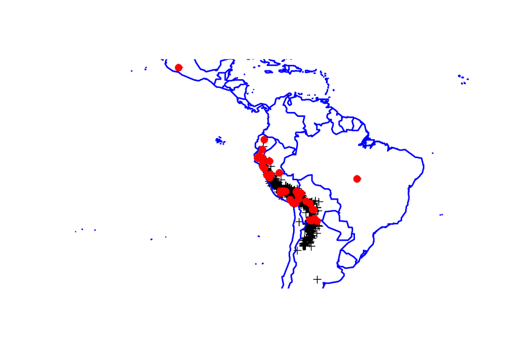

```r
plot(acg)
plot(wrld_simpl, add=T, border='blue', lwd=2)
points(acg[j, ], col='red', pch=20, cex=2)
```

# Step 3: Deal with absence and background points

Some of the early species distribution model algorithms, such as Bioclim and Domain only use ’presence’ data in the modeling process. Other methods also use ’absence’ data or ’background’ data.

> 1. Absent data

If you want to have a non-NA-value data frame for your method, Here is the thing you could do.

First, there is a common methods to delete all NA values from a data frame. We can use na.omit() function to delete the rows that contains the NA data. For example, you only need longtitude and latitude values to draw your map, then, you can take those two columns into a data frame.

```r
long<-acaule$lon
#extract column of longtitude
lati<-acaule$lat
#extract column of latitude

d<-cbind(long,lati)
#combine into a data frame
colnames(d)<-c("longitude","latitude")
#name data frame

dim(d)[1]
```

```
## [1] 7229
```

```r
#rows number of uncleaning data frame

d[27,]
```

```
## longitude  latitude
##        NA        NA
```

```r
#a NA rows in this data frame
```

Then, you can use na.omit() to delete all NA value from this data frame.

```r
clean_d <-na.omit(d)
#save teh cleaing data frame

dim(clean_d)[1]
```

```
## [1] 4643
```

```r
#rows number of cleaning data frame

clean_d[27,]
```

```
## longitude  latitude
## -67.71306 -28.97167
```

```r
#NA have been removed from the previous row.
```

A simple way to do this is filter function: filter() in dplyr package. For example:

```r
library(dplyr)
new_d<-filter(acaule, lon !="NA" & lat !="NA" )
#new variable to store the data frame.
summary(is.na(new_d$lon))
```

```
##    Mode   FALSE
## logical    4643
```

```r
#use is.na() to check if there is remaining NA in longitude column.
```

> 2. Backgroud data

Background data are not attempting to guess at absence locations, but rather to characterize environments in the study region. In this sense, background is the same, irrespective of where the species has been found.

Background data establishes the environmental domain of the study, whilst presence data should establish under which conditions a species is more likely to be present than on average. A closely related but different concept, that of “pseudo-absences”, is also used for generating the non-presence class for logistic models. In this case, researchers sometimes try to guess where absences might occur – they may sample the whole region except at presence locations, or they might sample at places unlikely to be suitable for the species. We prefer the background concept because it requires fewer assumptions and has some coherent statistical methods for dealing with the “overlap” between presence and background points.

In the example below, we first get the list of filenames with the predictor raster data (discussed in detail in the next section raster). We use a raster as a ‘mask’ in the randomPoints function such that the background points are from the same geographic area, and only for places where there are values (land, in our case).

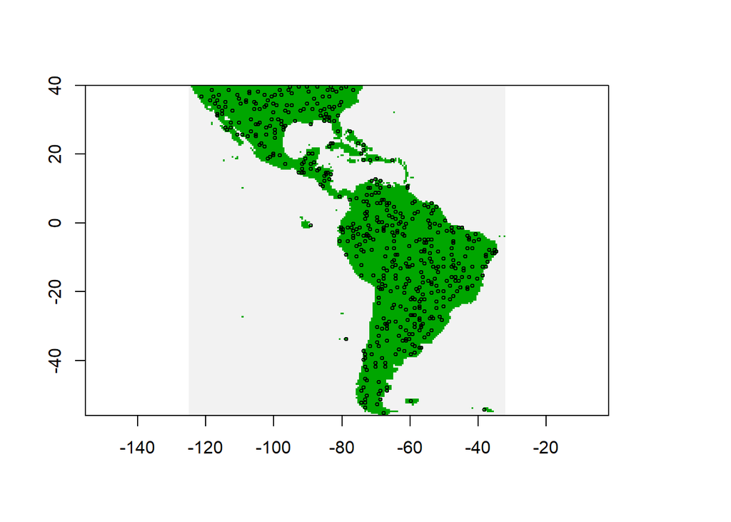

```r
library(dismo)
# get the file names
files <- list.files(path=paste(system.file(package="dismo"), '/ex',
                       sep=''),  pattern='grd',  full.names=TRUE )
# we use the first file to create a RasterLayer
mask <- raster(files[1])
# select 500 random points

set.seed(1963)
# set seed to assure that the examples will always have the same random sample.

bg <- randomPoints(mask, 500 )

plot(!is.na(mask), legend=FALSE)

points(bg, cex=0.5)
```

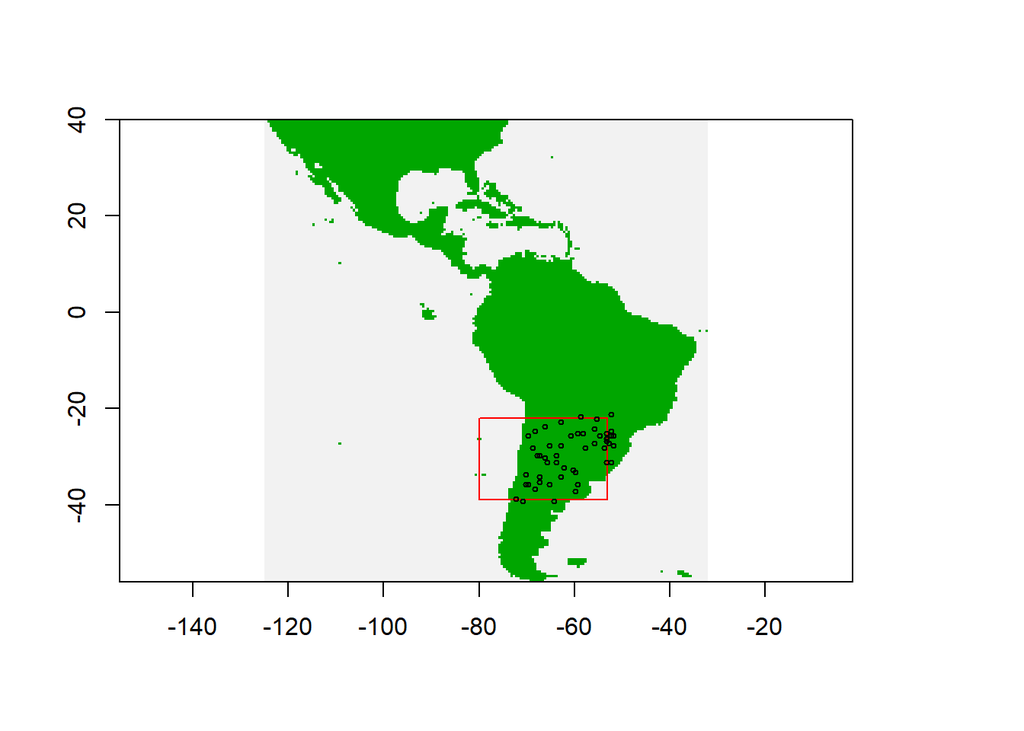

```r
# now we repeat the sampling, but limit the area of sampling using a spatial extent
e <- extent(-80, -53, -39, -22)
bg2 <- randomPoints(mask, 50, ext=e)
#limit point for longitude -39~-22, latitude -80~-53

plot(!is.na(mask), legend=FALSE)
plot(e, add=TRUE, col='red')
points(bg2, cex=0.5)
```

There are several approaches one could use to sample ‘pseudo-absence’ points from more restricted area than ‘background’. We first read the cleaned and subsetted S. acaule data that we produced in the previous chapter from the csv file that comes with dismo:

```r
file <- paste(system.file(package="dismo"), '/ex/acaule.csv', sep='')
ac <- read.csv(file)
#load the cleaned data file

coordinates(ac) <- ~lon+lat
projection(ac) <- CRS('+proj=longlat +datum=WGS84')
#create a Spatial Points Data Frame
```

We first create a ‘circles’ model (see the chapter about geographic models), using an arbitrary radius of 50 km. Circles() is a function from rgeos package.

```r
library(rgeos)
x <- circles(ac, d=50000, lonlat=TRUE)
# circles with a radius of 50 km
pol <- polygons(x)

samp1 <- spsample(pol, 250, type='random', iter=25)
# sample randomly from all circles

cells <- cellFromXY(mask, samp1)
length(cells)
```

```
## [1] 250
```

```r
cells <- unique(cells)
# get unique cells
length(cells)
```

```
## [1] 161
```

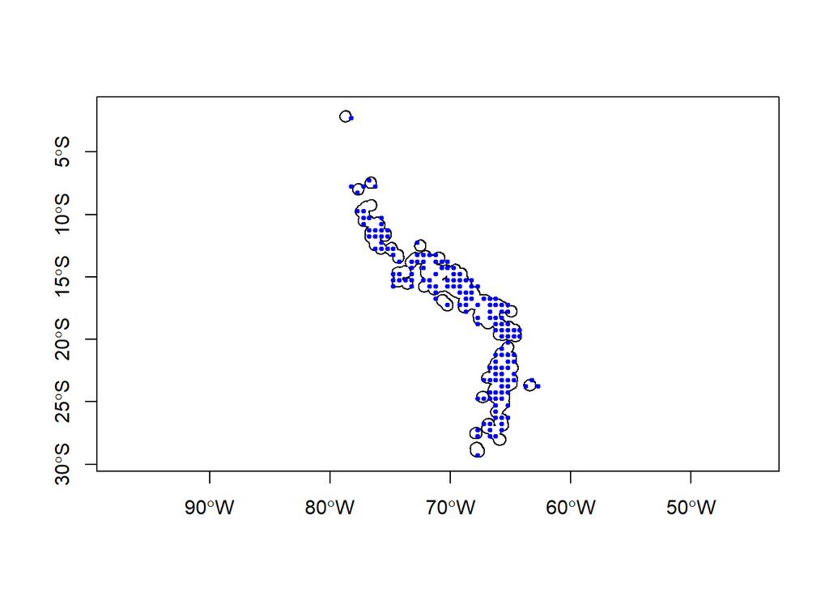

```r
xy <- xyFromCell(mask, cells)
plot(pol, axes=TRUE)
points(xy, cex=0.75, pch=20, col='blue')
```

```r
#make a plot to see results
```

A similar results could be produced via raster function extract()

```r
# extract cell numbers for the circles
v <- extract(mask, x@polygons, cellnumbers=T)
# use rbind to combine the elements in list v
v <- do.call(rbind, v)
# get unique cell numbers from which you could sample
v <- unique(v[,1])
head(v)
```

```
## [1] 15531 15717 17581 17582 17765 17767
```

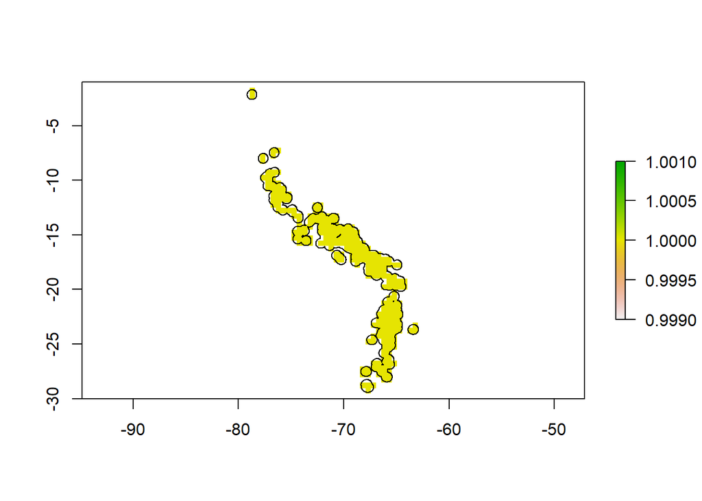

```r
# to display the results

m <- mask
m[] <- NA
m[v] <- 1
plot(m, ext=extent(x@polygons)+1)
plot(x@polygons, add=T)
```

```r
# make a plot for results,
```

# step 4: Use R package Raster to analysis data

> Raster data

A raster consists of a matrix of cells (or pixels) organized into rows and columns (or a grid) where each contains a value representing information. Raster format represents real-world phenomena, data might be discrete or continuous. Discrete data: also are called thematic, categorical or discontinuous data. A discrete object has known and definable boundaries.

In species distribution modeling, predictor variables are typically organized as raster (grid) type files. Each predictor should be a ‘raster’ representing a variable of interest. Variables can include climatic, soil, terrain, vegetation, land use, and other variables.

These data are typically stored in files in some kind of GIS format. Almost all relevant formats can be used (including ESRI grid, geoTiff, netCDF, IDRISI).

For any particular study the layers should all have the same spatial extent, resolution, origin, and projection. The set of predictor variables (rasters) can be used to make a RasterStack, which is a collection of `RasterLayer’ objects

A RasterLayer object represents single-layer (variable) raster data. A RasterLayer object always stores a number of fundamental parameters that describe it. These include the number of columns and rows, the spatial extent, and the Coordinate Reference System. In addition, a RasterLayer can store information about the file in which the raster cell values are stored (if there is such a file). A RasterLayer can also hold the raster cell values in memory.

Using the dismo package we are going to create a rasterStack from the list of files are intalled in the package. Fist, we need to get the folder with our files…..

```r
path <- file.path(system.file(package="dismo"), 'ex')
```

Now get the names of all the files with extension “.grd” in this folder. The $ sign indicates that the files must end with the characters ‘grd’. By using full.names=TRUE, the full path names are retunred.

```r
library(dismo)
files <- list.files(path, pattern='grd$', full.names=TRUE )
files
```

```
## [1] "C:/Users/feiyawang/Documents/R/win-library/3.6/dismo/ex/bio1.grd"
## [2] "C:/Users/feiyawang/Documents/R/win-library/3.6/dismo/ex/bio12.grd"
## [3] "C:/Users/feiyawang/Documents/R/win-library/3.6/dismo/ex/bio16.grd"
## [4] "C:/Users/feiyawang/Documents/R/win-library/3.6/dismo/ex/bio17.grd"
## [5] "C:/Users/feiyawang/Documents/R/win-library/3.6/dismo/ex/bio5.grd"
## [6] "C:/Users/feiyawang/Documents/R/win-library/3.6/dismo/ex/bio6.grd"
## [7] "C:/Users/feiyawang/Documents/R/win-library/3.6/dismo/ex/bio7.grd"
## [8] "C:/Users/feiyawang/Documents/R/win-library/3.6/dismo/ex/bio8.grd"
## [9] "C:/Users/feiyawang/Documents/R/win-library/3.6/dismo/ex/biome.grd"
```

Now create a RasterStack of predictor variables.

```r
predictors <- stack(files)
predictors
```

```
## class      : RasterStack
## dimensions : 192, 186, 35712, 9  (nrow, ncol, ncell, nlayers)
## resolution : 0.5, 0.5  (x, y)
## extent     : -125, -32, -56, 40  (xmin, xmax, ymin, ymax)
## crs        : +proj=longlat +datum=WGS84 +ellps=WGS84 +towgs84=0,0,0
## names      : bio1, bio12, bio16, bio17, bio5, bio6, bio7, bio8, biome
## min values :  -23,     0,     0,     0,   61, -212,   60,  -66,     1
## max values :  289,  7682,  2458,  1496,  422,  242,  461,  323,    14
```

```r
names(predictors)
```

```
## [1] "bio1"  "bio12" "bio16" "bio17" "bio5"  "bio6"  "bio7"  "bio8"  "biome"
```

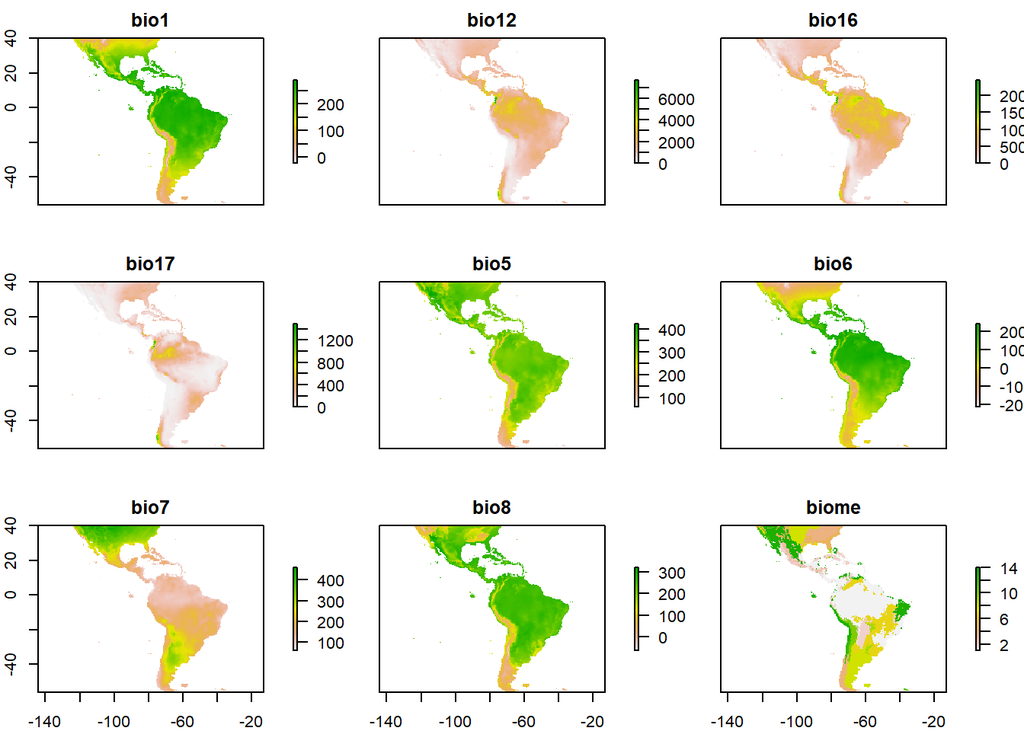

```r
plot(predictors)
```

We can also make a plot of a single layer in a RasterStack, and plot some additional data on top of it. First get the world boundaries and the bradypus data:

```r
library(maptools)
data(wrld_simpl)
file <- paste(system.file(package="dismo"), "/ex/bradypus.csv", sep="")
bradypus <- read.table(file,  header=TRUE,  sep=',')
# we do not need the first column
bradypus  <- bradypus[,-1]
```

Plotting bioclimatic variables from WorldClim database

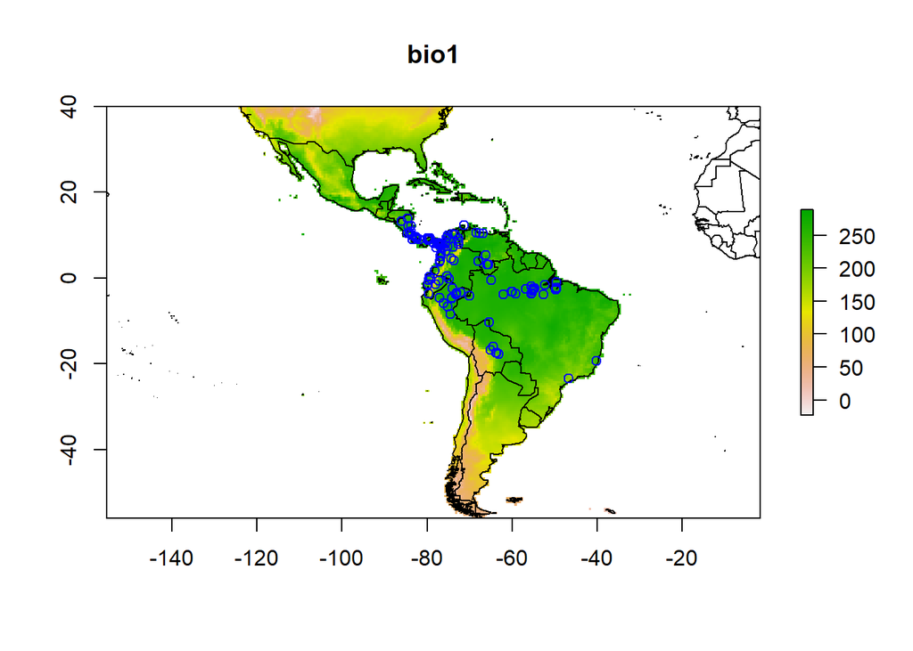

```r
# first layer of the RasterStack
plot(predictors, 1)
# note the "add=TRUE" argument with plot
plot(wrld_simpl, add=TRUE)
# with the points function, "add" is implicit
points(bradypus, col='blue')
```

> Extracting values from rasters

We now have a set of predictor variables (rasters) and occurrence points. The next step is to extract the values of the predictors at the locations of the points. (This step can be skipped for the modeling methods that are implemented in the dismo package). This is a very straightforward thing to do using the ‘extract’ function from the raster package.

```r
presvals <- extract(predictors, bradypus)
# setting random seed to always create the same
# random set of points for this example
set.seed(0)
#Set the seed of R's random number generator, which is useful for creating simulations or random objects that can be reproduced

backgr <- randomPoints(predictors, 500)
#setting for backgroud

absvals <- extract(predictors, backgr)
#extract values

pb <- c(rep(1, nrow(presvals)), rep(0, nrow(absvals)))

sdmdata <- data.frame(cbind(pb, rbind(presvals, absvals)))

sdmdata[,'biome'] = as.factor(sdmdata[,'biome'])

head(sdmdata)
```

```
##   pb bio1 bio12 bio16 bio17 bio5 bio6 bio7 bio8 biome
## 1  1  263  1639   724    62  338  191  147  261     1
## 2  1  263  1639   724    62  338  191  147  261     1
## 3  1  253  3624  1547   373  329  150  179  271     1
## 4  1  243  1693   775   186  318  150  168  264     1
## 5  1  243  1693   775   186  318  150  168  264     1
## 6  1  252  2501  1081   280  326  154  172  270     1
```

```r
tail(sdmdata)
```

```
##     pb bio1 bio12 bio16 bio17 bio5 bio6 bio7 bio8 biome
## 611  0  265  1622   749    66  344  184  160  266     1
## 612  0  241  1648   475   354  294  183  112  229     1
## 613  0  154   731   250    80  319   18  301  198     8
## 614  0  169  1195   316   273  293   69  224  122     7
## 615  0  247  2965  1173   327  314  168  146  253     1
## 616  0  117   495   231    36  336  -96  432  216     8
```

```r
summary(sdmdata)
```

```
##        pb              bio1           bio12            bio16
##  Min.   :0.0000   Min.   : 16.0   Min.   :   0.0   Min.   :   0.0
##  1st Qu.:0.0000   1st Qu.:176.8   1st Qu.: 821.5   1st Qu.: 341.8
##  Median :0.0000   Median :242.0   Median :1497.0   Median : 645.5
##  Mean   :0.1883   Mean   :213.9   Mean   :1629.5   Mean   : 656.4
##  3rd Qu.:0.0000   3rd Qu.:261.0   3rd Qu.:2266.8   3rd Qu.: 917.0
##  Max.   :1.0000   Max.   :286.0   Max.   :7682.0   Max.   :2458.0
##
##      bio17             bio5            bio6             bio7
##  Min.   :   0.0   Min.   : 88.0   Min.   :-167.0   Min.   : 68.0
##  1st Qu.:  42.0   1st Qu.:303.0   1st Qu.:  45.0   1st Qu.:118.8
##  Median : 110.0   Median :320.0   Median : 151.0   Median :160.0
##  Mean   : 169.2   Mean   :309.3   Mean   : 119.3   Mean   :190.0
##  3rd Qu.: 240.5   3rd Qu.:333.0   3rd Qu.: 202.2   3rd Qu.:247.0
##  Max.   :1496.0   Max.   :410.0   Max.   : 232.0   Max.   :440.0
##
##       bio8           biome
##  Min.   :-20.0   1      :299
##  1st Qu.:215.0   7      : 65
##  Median :250.0   8      : 61
##  Mean   :225.1   13     : 51
##  3rd Qu.:262.0   2      : 49
##  Max.   :323.0   4      : 33
##                  (Other): 58
```

To visually investigate colinearity in the environmental data (at the presence and background points) you can use a pairs plot.

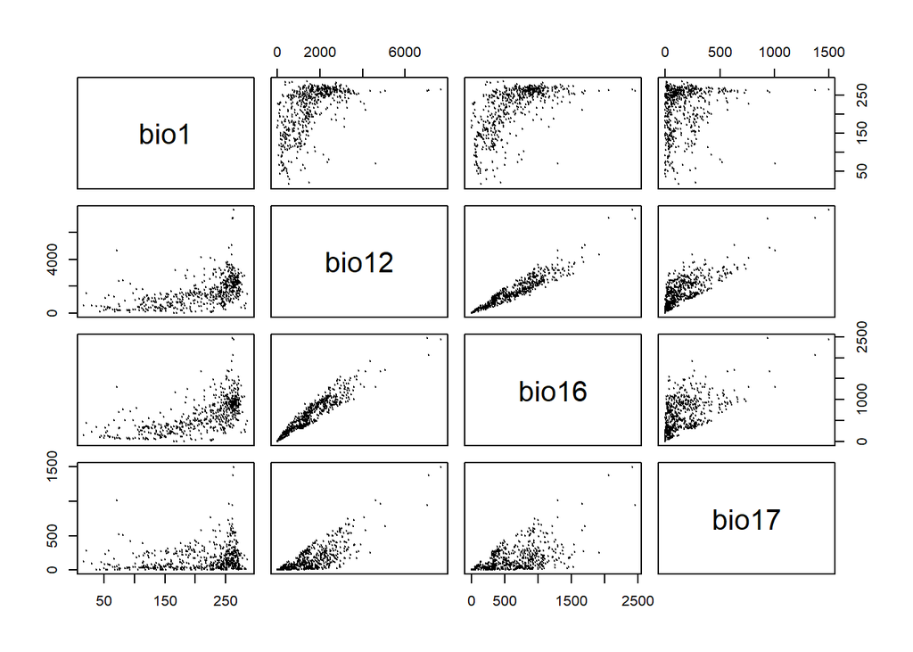

```r
pairs(sdmdata[,2:5], cex=0.1)
```

# Step 5: Picking models

A large number of algorithms has been used in species distribution modeling. They can be classified as ‘profile’, ‘regression’, and ‘machine learning’ methods. Profile methods only consider ‘presence’ data, not absence or background data. Regression and machine learning methods use both presence and absence or background data. The distinction between regression and machine learning methods is not sharp, but it is perhaps still useful as way to classify models. Another distinction that one can make is between presence-only and presence-absence models. Profile methods are always presence-only, other methods can be either, depending if they are used with survey-absence or with pseudo-absence/background data. An entirely different class of models consists of models that only, or primarily, use the geographic location of known occurrences, and do not rely on the values of predictor variables at these locations. We refer to these models as ‘geographic models’.

> Profile model:

Bioclim, Domain, and Mahal are methods from profile mothods.These methods are implemented in the dismo package, and the procedures to use these models are the same for all three.

> Regression model:

We lean classic regression model from class. it is very similar here. Models are fit using maximum likelihood and by allowing the model to be related to the response variable via a link function and by allowing the magnitude of the variance of each measurement to be a function of its predicted value

> Machine learning models:

Machine learning models are non-parametric flexible regression models. Methods include Artifical Neural Networks (ANN), Random Forests, Boosted Regression Trees, and Support Vector Machines. Through the dismo package you can also use the Maxent program, that implements the most widely used method (maxent) in species distribution modeling.

> Example: Generalized Linear Models

A generalized linear model (GLM) is a generalization of ordinary least squares regression. Models are fit using maximum likelihood and by allowing the linear model to be related to the response variable via a link function and by allowing the magnitude of the variance of each measurement to be a function of its predicted value. Depending on how a GLM is specified it can be equivalent to (multiple) linear regression, logistic regression or Poisson regression

In R, GLM is implemented in the ‘glm’ function, and the link function and error distribution are specified with the ‘family’ argument. Examples are:

*family = binomial(link = “logit”)

*family = poisson(link = “log”)

Here we fit two basic glm models. The models need to be fit with presence and absence (background) data. With the exception of ‘maxent’, we cannot fit the model with a RasterStack and points. Instead, we need to extract the environmental data values ourselves, and fit the models with these values.

```r
#first example
gm1 <- glm(pa ~ bio1 + bio5 + bio6 + bio7 + bio8 + bio12 + bio16 + bio17,
            family = binomial(link = "logit"), data=envtrain)
summary(gm1)
```

```
##
## Call:
## glm(formula = pa ~ bio1 + bio5 + bio6 + bio7 + bio8 + bio12 +
##     bio16 + bio17, family = binomial(link = "logit"), data = envtrain)
##
## Deviance Residuals:
##      Min        1Q    Median        3Q       Max
## -1.73157  -0.48749  -0.23064  -0.05455   2.90207
##
## Coefficients:
##               Estimate Std. Error z value Pr(>|z|)
## (Intercept)  2.4189152  1.6563006   1.460  0.14417
## bio1         0.1083418  0.0609904   1.776  0.07567 .
## bio5         0.1010893  0.2526065   0.400  0.68902
## bio6        -0.1941921  0.2545272  -0.763  0.44549
## bio7        -0.1875595  0.2530838  -0.741  0.45864
## bio8        -0.0180964  0.0275002  -0.658  0.51051
## bio12        0.0018953  0.0007034   2.695  0.00705 **
## bio16       -0.0019137  0.0014796  -1.293  0.19586
## bio17       -0.0042036  0.0015431  -2.724  0.00645 **
## ---
## Signif. codes:  0 '***' 0.001 '**' 0.01 '*' 0.05 '.' 0.1 ' ' 1
##
## (Dispersion parameter for binomial family taken to be 1)
##
##     Null deviance: 596.69  on 892  degrees of freedom
## Residual deviance: 440.50  on 884  degrees of freedom
## AIC: 458.5
##
## Number of Fisher Scoring iterations: 8
```

```r
coef(gm1)
```

```
##  (Intercept)         bio1         bio5         bio6         bio7
##  2.418915241  0.108341785  0.101089299 -0.194192095 -0.187559462
##         bio8        bio12        bio16        bio17
## -0.018096425  0.001895285 -0.001913743 -0.004203616
```

```r
#second example
gm2 <- glm(pa ~ bio1+bio5 + bio6 + bio7 + bio8 + bio12 + bio16 + bio17,
            family = gaussian(link = "identity"), data=envtrain)
evaluate(testpres, testbackg, gm1)
```

```
## class          : ModelEvaluation
## n presences    : 23
## n absences     : 200
## AUC            : 0.7938043
## cor            : 0.2640135
## max TPR+TNR at : -2.844012
```

```r
ge2 <- evaluate(testpres, testbackg, gm2)
ge2
```

```
## class          : ModelEvaluation
## n presences    : 23
## n absences     : 200
## AUC            : 0.7801087
## cor            : 0.2952745
## max TPR+TNR at : 0.05090658
```

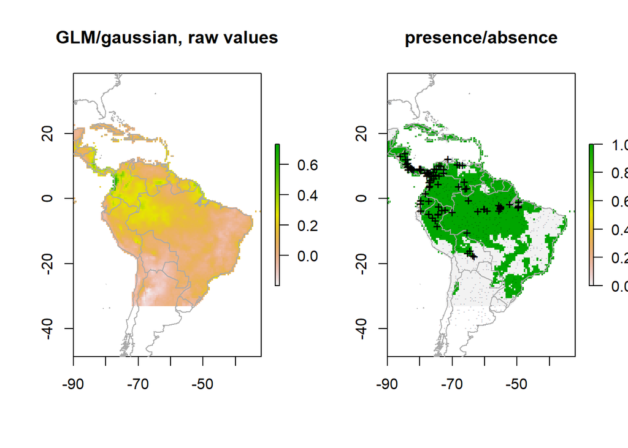

```r
#show as a plot graph
pg <- predict(predictors, gm2, ext=ext)
par(mfrow=c(1,2))
plot(pg, main='GLM/gaussian, raw values')
plot(wrld_simpl, add=TRUE, border='dark grey')
tr <- threshold(ge2, 'spec_sens')
plot(pg > tr, main='presence/absence')
plot(wrld_simpl, add=TRUE, border='dark grey')
points(pres_train, pch='+')
points(backg_train, pch='-', cex=0.25)
```

# Step 6: Model evaluation

Most model types have different measures that can help to assess how good the model fits the data. Most statistics or machine learning texts will provide some details. For instance, for a GLM one can look at how much deviance is explained, whether there are patterns in the residuals, whether there are points with high leverage and so on. However, since many models are to be used for prediction, much evaluation is focused on how well the model predicts to points not used in model training. What do we consider to evaluate a model?

Does the model seem sensible, ecologically? Do the fitted functions (the shapes of the modeled relationships) make sense? Do the predictions seem reasonable? (map them, and think about them)? Are there any spatial patterns in model residuals?

Different measures can be used to evaluate the quality of a prediction, perhaps depending on the goal of the study. Many measures for evaluating models based on presence-absence or presence-only data are ‘threshold dependent’. That means that a threshold must be set first (e.g., 0.5, though 0.5 is rarely a sensible choice – e.g. see Lui et al. 2005). Predicted values above that threshold indicate a prediction of ‘presence’, and values below the threshold indicate ‘absence’. Some measures emphasize the weight of false absences; others give more weight to false presences.

Much used statistics that are threshold independent are the correlation coefficient and the Area Under the Receiver Operator Curve (AUROC, generally further abbreviated to AUC). AUC is a measure of rank-correlation. In unbiased data, a high AUC indicates that sites with high predicted suitability values tend to be areas of known presence and locations with lower model prediction values tend to be areas where the species is not known to be present (absent or a random point). An AUC score of 0.5 means that the model is as good as a random guess.

Here we illustrate the computation of the correlation coefficient and AUC with two random variables. p (presence) has higher values, and represents the predicted value for 50 known cases (locations) where the species is present, and a (absence) has lower values, and represents the predicted value for 50 known cases (locations) where the species is absent.

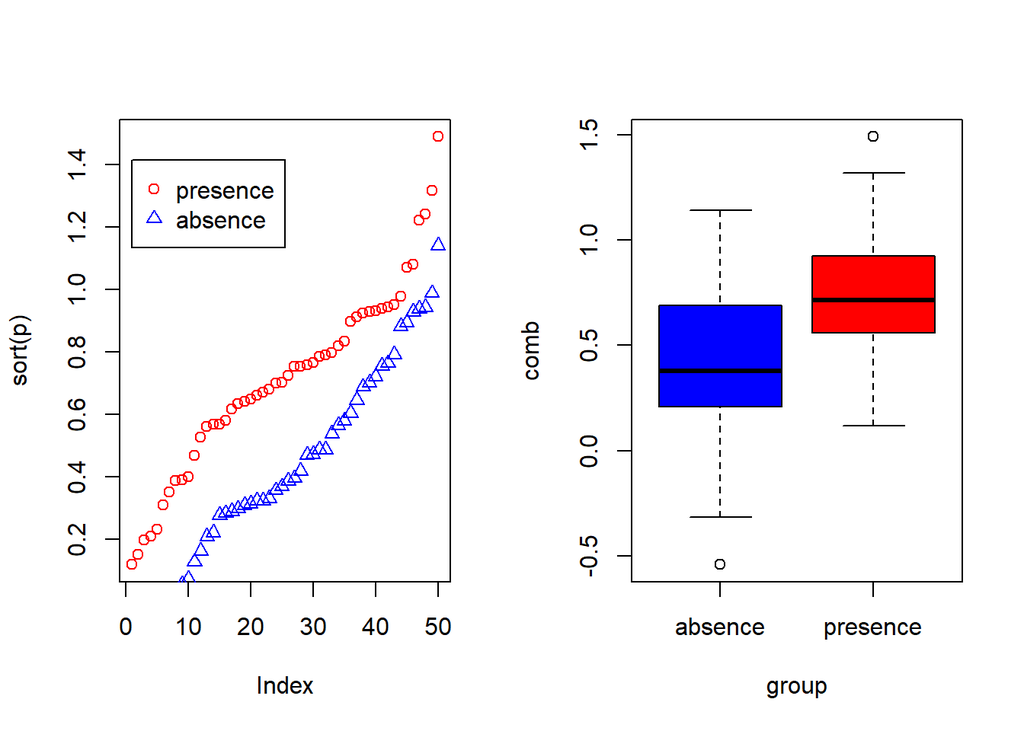

```r
p <- rnorm(50, mean=0.7, sd=0.3)
a <- rnorm(50, mean=0.4, sd=0.4)
par(mfrow=c(1, 2))
plot(sort(p), col='red', pch=21)
points(sort(a), col='blue', pch=24)
legend(1, 0.95 * max(a,p), c('presence', 'absence'),
          pch=c(21,24), col=c('red', 'blue'))
comb <- c(p,a)
group <- c(rep('presence', length(p)), rep('absence', length(a)))
boxplot(comb~group, col=c('blue', 'red'))
```

We created two variables with random normally distributed values, but with different mean and standard deviation. The two variables clearly have different distributions, and the values for ‘presence’ tend to be higher than for ‘absence’. Here is how you can compute the correlation coefficient and the AUC:

```r
group = c(rep(1, length(p)), rep(0, length(a)))
cor.test(comb, group)$estimate
```

```
##       cor
## 0.4224299
```

```r
mv <- wilcox.test(p,a)
auc <- as.numeric(mv$statistic) / (length(p) * length(a))
auc
```

```
## [1] 0.7368
```

Below we show how you can compute these, and other statistics more conveniently, with the evaluate function in the dismo package. See ?evaluate for info on additional evaluation measures that are available. ROC/AUC can also be computed with the ROCR package.

```r
e <- evaluate(p=p, a=a)
class(e)
```

```
## [1] "ModelEvaluation"
## attr(,"package")
## [1] "dismo"
```

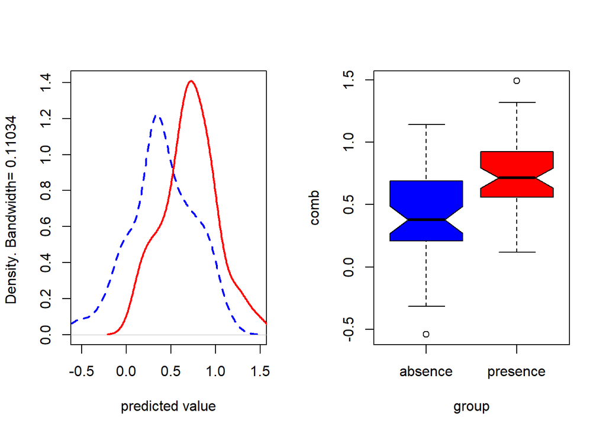

```r
par(mfrow=c(1, 2))
density(e)
boxplot(e, col=c('blue', 'red'))
```

Back to some real data, presence-only in this case. We’ll divide the data in two random sets, one for training a Bioclim model, and one for evaluating the model.

```r
samp <- sample(nrow(sdmdata), round(0.75 * nrow(sdmdata)))
traindata <- sdmdata[samp,]
traindata <- traindata[traindata[,1] == 1, 2:9]
testdata <- sdmdata[-samp,]
bc <- bioclim(traindata)
e <- evaluate(testdata[testdata==1,], testdata[testdata==0,], bc)
e
```

```
## class          : ModelEvaluation
## n presences    : 25
## n absences     : 129
## AUC            : 0.756124
## cor            : 0.2518402
## max TPR+TNR at : 0.01088901
```

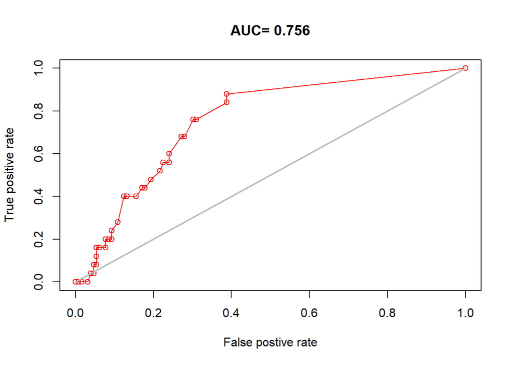

```r
plot(e, 'ROC')
```

Let’s first create presence and background data.

```r
pres <- sdmdata[sdmdata[,1] == 1, 2:9]
back <- sdmdata[sdmdata[,1] == 0, 2:9]
```

The background data will only be used for model testing and does not need to be partitioned. We now partition the data into 5 groups

```r
k <- 5
group <- kfold(pres, k)
group[1:10]
```

```
##  [1] 3 2 2 4 3 2 3 1 1 2
```

```r
unique(group)
```

```
## [1] 3 2 4 1 5
```

Now we can fit and test our model five times. In each run, the records corresponding to one of the five groups is only used to evaluate the model, while the other four groups are only used to fit the model. The results are stored in a list called ‘e’.

```r
e <- list()
for (i in 1:k) {
    train <- pres[group != i,]
    test <- pres[group == i,]
    bc <- bioclim(train)
    e[[i]] <- evaluate(p=test, a=back, bc)
}
```

We can extract several things from the objects in ‘e’, but let’s restrict ourselves to the AUC values and the “maximum of the sum of the sensitivity (true positive rate) and specificity (true negative rate)” threshold “spec_sens” (this is sometimes uses as a threshold for setting cells to presence or absence).

```r
auc <- sapply(e, function(x){x@auc})
auc
```

```
## [1] 0.7800000 0.7756522 0.8173750 0.7817826 0.7738696
```

```r
mean(auc)
```

```
## [1] 0.7857359
```

```r
sapply( e, function(x){ threshold(x)['spec_sens'] } )
```

```
## $spec_sens
## [1] 0.04291075
##
## $spec_sens
## [1] 0.08592151
##
## $spec_sens
## [1] 0.01076957
##
## $spec_sens
## [1] 0.04291075
##
## $spec_sens
## [1] 0.03215806
```

The use of AUC in evaluating SDMs has been criticized (Lobo et al. 2008, Jiménez-Valverde 2011). A particularly sticky problem is that the values of AUC vary with the spatial extent used to select background points. Generally, the larger that extent, the higher the AUC value. Therefore, AUC values are generally biased and cannot be directly compared. Hijmans (2012) suggests that one could remove “spatial sorting bias” (the difference between the distance from testing-presence to training-presence and the distance from testing-absence to training-presence points) through “point-wise distance sampling”.

```r
file <- file.path(system.file(package="dismo"), "ex/bradypus.csv")
bradypus <- read.table(file,  header=TRUE,  sep=',')
bradypus <- bradypus[,-1]
presvals <- extract(predictors, bradypus)
set.seed(0)
backgr <- randomPoints(predictors, 500)
nr <- nrow(bradypus)
s <- sample(nr, 0.25 * nr)
pres_train <- bradypus[-s, ]
pres_test <- bradypus[s, ]
nr <- nrow(backgr)
set.seed(9)
s <- sample(nr, 0.25 * nr)
back_train <- backgr[-s, ]
back_test <- backgr[s, ]
```

```r
sb <- ssb(pres_test, back_test, pres_train)
sb[,1] / sb[,2]
```

```
##         p
## 0.1000638
```

sb[,1] / sb[,2] is an indicator of spatial sorting bias (SSB). If there is no SSB this value should be 1, in these data it is close to zero, indicating that SSB is very strong. Let’s create a subsample in which SSB is removed.

```r
i <- pwdSample(pres_test, back_test, pres_train, n=1, tr=0.1)
pres_test_pwd <- pres_test[!is.na(i[,1]), ]
back_test_pwd <- back_test[na.omit(as.vector(i)), ]
sb2 <- ssb(pres_test_pwd, back_test_pwd, pres_train)
sb2[1]/ sb2[2]
```

```
## [1] 1.004106
```

Spatial sorting bias is much reduced now; notice how the AUC dropped!

```r
bc <- bioclim(predictors, pres_train)
evaluate(bc, p=pres_test, a=back_test, x=predictors)
```

```
## class          : ModelEvaluation
## n presences    : 29
## n absences     : 125
## AUC            : 0.757931
## cor            : 0.2777298
## max TPR+TNR at : 0.03438276
```

```r
evaluate(bc, p=pres_test_pwd, a=back_test_pwd, x=predictors)
```

```
## class          : ModelEvaluation
## n presences    : 19
## n absences     : 19
## AUC            : 0.5914127
## cor            : 0.1487003
## max TPR+TNR at : 0.09185402
```

# References

1. Hijmans RJ, Elith J (2012) Species distribution modeling with R. http://cran.r-project.org/web/packages/dismo/vignettes/dm.pdf.
2. Elith, J., C.H. Graham, R.P. Anderson, M. Dudik, S. Ferrier, A. Guisan, R.J. Hijmans, F. Huettmann, J. Leathwick, A. Lehmann, J. Li, L.G. Lohmann, B. Loiselle, G. Manion, C. Moritz, M. Nakamura, Y. Nakazawa, J. McC. Overton, A.T. Peterson, S. Phillips, K. Richardson, R. Scachetti-Pereira, R. Schapire, J. Soberon, S. Williams, M. Wisz and N. Zimmerman, 2006. Novel methods improve prediction of species’ distributions from occurrence data. Ecography 29: 129-151.